# Human activity recognition with wearable accelerometers: course project

Chun Fang

11/27/2016

## Introduction

Using devices such as Jawbone Up, Nike FuelBand, and Fitbit it is now possible to collect a large amount of data about personal activity relatively inexpensively. These type of devices are part of the quantified self movement – a group of enthusiasts who take measurements about themselves regularly to improve their health, to find patterns in their behavior, or because they are tech geeks. One thing that people regularly do is quantify how much of a particular activity they do, but they rarely quantify how well they do it.

In this project, we try to train a model base on the data from accelerometers on the belt, forearm, arm, and dumbell of 6 participants, who were asked to perform barbell lifts correctly and incorrectly in 5 different ways. We use this model to predict the manner in which they did the exercise, which corresponding to the “classe” variable of data set.

## Data

The training data used for this project are available here:

https://d396qusza40orc.cloudfront.net/predmachlearn/pml-training.csv

The test data are available here:

https://d396qusza40orc.cloudfront.net/predmachlearn/pml-testing.csv

The data for this project come from the source: http://groupware.les.inf.puc-rio.br/har

We download these data and save them in a separate folder, named “data”, of present work directory of R.

```r
fileUrl_train <- "https://d396qusza40orc.cloudfront.net/predmachlearn/pml-training.csv"
fileUrl_test <- "https://d396qusza40orc.cloudfront.net/predmachlearn/pml-testing.csv"
if (!file.exists("./data")) {
    dir.create("./data")
}
if (!file.exists("./data/pml-training.csv")) {
    download.file(fileUrl_train, destfile = "./data/pml-training.csv")
}
if (!file.exists("./data/pml-testing.csv")) {
    download.file(fileUrl_test, destfile = "./data/pml-testing.csv")
}
```

## Pre-Processing

In this section, we will detect the data and do exploratory analysis.

First, load and check the data. Note that the missing value are coded as strings “NA”, “#DIV/0!” or “”.

```r
pml_train <- read.csv(file = "./data/pml-training.csv", na.strings=c("NA","#DIV/0!", ""))
pml_test <- read.csv(file = "./data/pml-testing.csv", na.strings=c("NA","#DIV/0!", ""))
str(pml_train)
```

```r
if (!file.exists("./data/pml_train_NA.csv")) {
    write.csv(pml_train, file = "./data/pml_train_NA.csv")
}
```

After checking the data, i.e., $pml\_train\_NA.csv$, one can find there are lots of “NA” values. Therefore, it is better to remove those variables whose proportion of “NA” are bigger than 95%.

```r
l <- dim(pml_train)[2]
n <- dim(pml_train)[1]
NA_var_95 <- rep(0, l)
for (i in 1:l) {
    if (sum(is.na(pml_train[, i])) / n > 0.95) {
        NA_var_95[i] = 1
    }
}
```

```r
library(dplyr)
pml_train_noNA <- select(pml_train, which(NA_var_95==0))
pml_test_noNA <- select(pml_test, which(NA_var_95==0))
```

Take a look at the data again.

```r
str(pml_train_noNA)
summary(pml_train_noNA)
```

```r
pml_train_pre <- select(pml_train_noNA, -c(X, user_name, raw_timestamp_part_1,
                                            raw_timestamp_part_2, cvtd_timestamp,
                                            new_window, num_window))
pml_test_pre <- select(pml_test_noNA, -c(X, user_name, raw_timestamp_part_1,
                                            raw_timestamp_part_2, cvtd_timestamp,
                                            new_window, num_window))
```

## Modeling and training

Recall that we aim to find a model with good prediction accuracy. Random forest algorithm is a good choice, at least should not worse than linear classification. Of course, for a better prediction, one can also try ensemble learning. But we only use the first mentioned method in this project.

```r
library(caret)
set.seed(1)
inTrain <- createDataPartition(pml_train_pre$classe, p = 0.8, list = FALSE)
training <- pml_train_pre[inTrain, ]
testing <- pml_train_pre[-inTrain, ]
```

```r
library(randomForest)
rfModel <- randomForest(classe ~ ., data = training, importance = TRUE)
prediction_train <- predict(rfModel, training)
confusionMatrix(prediction_train, training$classe)
```

[output not shown]

Here is the cross validation part.

```r
prediction_test <- predict(rfModel, testing)
confusionMatrix(prediction_test, testing$classe)
```

```
## $positive
## NULL
##
## $table
##           Reference
## Prediction    A    B    C    D    E
##          A 1115    2    0    0    0
##          B    1  756    5    0    0
##          C    0    1  676    7    0
##          D    0    0    3  634    1
##          E    0    0    0    2  720
##
## $overall
##       Accuracy          Kappa  AccuracyLower  AccuracyUpper   AccuracyNull
##      0.9943920      0.9929062      0.9915217      0.9964823      0.2844762
## AccuracyPValue  McnemarPValue
##      0.0000000            NaN
##
## $byClass
##          Sensitivity Specificity Pos Pred Value Neg Pred Value Precision
## Class: A   0.9991039   0.9992875      0.9982095      0.9996436 0.9982095
## Class: B   0.9960474   0.9981037      0.9921260      0.9990509 0.9921260
## Class: C   0.9883041   0.9975301      0.9883041      0.9975301 0.9883041
## Class: D   0.9860031   0.9987805      0.9937304      0.9972603 0.9937304
## Class: E   0.9986130   0.9993754      0.9972299      0.9996876 0.9972299
##             Recall        F1 Prevalence Detection Rate
## Class: A 0.9991039 0.9986565  0.2844762      0.2842213
## Class: B 0.9960474 0.9940828  0.1934744      0.1927097
## Class: C 0.9883041 0.9883041  0.1743564      0.1723171
## Class: D 0.9860031 0.9898517  0.1639052      0.1616110
## Class: E 0.9986130 0.9979210  0.1837879      0.1835330
##          Detection Prevalence Balanced Accuracy
## Class: A            0.2847311         0.9991957
## Class: B            0.1942391         0.9970755
## Class: C            0.1743564         0.9929171
## Class: D            0.1626306         0.9923918
## Class: E            0.1840428         0.9989942
##
## $mode
## [1] "sens_spec"
##
## $dots
## list()
##
## attr(,"class")
## [1] "confusionMatrix"
```

## Prediction

Now we can make prediction for the given test set: $pml\_test\_pre$.

```r
predict_for_test <- predict(rfModel, pml_test_pre)
predict_for_test
```

```
##  1  2  3  4  5  6  7  8  9 10 11 12 13 14 15 16 17 18 19 20
##  B  A  B  A  A  E  D  B  A  A  B  C  B  A  E  E  A  B  B  B
## Levels: A B C D E
```

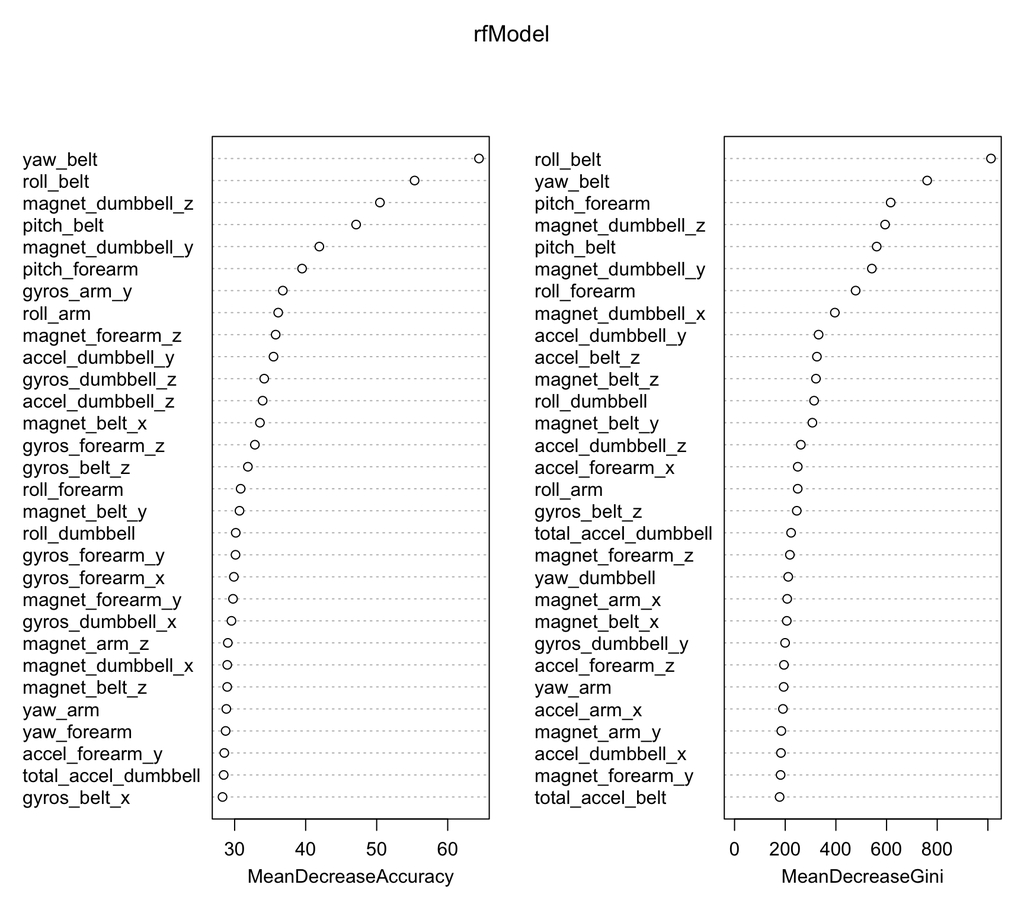

```r
varImpPlot(rfModel)
```